# project proposal

Mehdi Khan

October 25, 2017

load libraries:

```r
suppressMessages(suppressWarnings(library(dplyr)))
suppressMessages(suppressWarnings(library(stringr)))
suppressMessages(suppressWarnings(library(DATA606)))
```

[output not shown]

```r
suppressMessages(suppressWarnings(library(psych)))
suppressMessages(suppressWarnings(library(ggplot2)))
```

# data prepration:

Load data:

```r
originDS <- read.csv("https://raw.githubusercontent.com/kmehdi2017/projectProp/master/ProjectProposal/ACS_15_5YR_DP02_with_ann.csv",
    sep = ",", stringsAsFactors = FALSE)

head(originDS)
```

[output not shown]

[output cut: 4241 more lines]

The original data contains a lot of variable which are not relevant to this study, therefore a subset of the data is extracted. The following are the variables that are selected for the project as described below:

GEO.display.label: Geography HC01_VC03 Estimate; HOUSEHOLDS BY TYPE - Total households HC01_VC04: Estimate: Total households - Family households (families)  
HC01_VC06: Estimate: Total households - Family households (families) - Married-couple family  
HC01_VC08: Estimate: Total households - Family households (families) - Male householder, no wife present  
HC01_VC10: Estimate: Total households - Family households (families) - Female householder, no husband present HC01_VC76: Estimate: SCHOOL ENROLLMENT - Population 3 years and over enrolled in school HC01_VC88: Estimate: EDUCATIONAL ATTAINMENT - Population 25 years and over - High school graduate HC03_VC88: Percent: EDUCATIONAL ATTAINMENT - Population 25 years and over - High school graduate HC01_VC91: Estimate: EDUCATIONAL ATTAINMENT - Population 25 years and over - Bachelor’s degree HC03_VC91: Percent; EDUCATIONAL ATTAINMENT - Population 25 years and over - Bachelor’s degree

```r
vars <- c("GEO.display.label", "HC01_VC03", "HC01_VC04", "HC01_VC06",
    "HC01_VC08", "HC01_VC10", "HC01_VC76", "HC01_VC88", "HC03_VC88",
    "HC01_VC91", "HC03_VC91")

familyEduDS <- originDS[-1, vars]

head(familyEduDS)
```

```
##   GEO.display.label HC01_VC03 HC01_VC04 HC01_VC06 HC01_VC08 HC01_VC10
## 2           Alabama   1848325   1238967    880942     78073    279952
## 3            Alaska    250969    167562    124649     14733     28180
## 4           Arizona   2412212   1581380   1142828    131803    306749
## 5          Arkansas   1138025    759924    558920     50484    150520
## 6        California  12717801   8732734   6245351    759047   1728336
## 7          Colorado   2024468   1300972   1003324     91627    206021
##   HC01_VC76 HC01_VC88 HC03_VC88 HC01_VC91 HC03_VC91
## 2   1206014   1005295      31.0    478812      14.8
## 3    195151    129324      27.8     83201      17.9
## 4   1754549   1063765      24.4    753425      17.3
## 5    750024    685277      34.9    267741      13.6
## 6  10579176   5231824      20.7   5002596      19.8
## 7   1395787    767325      21.8    847977      24.1
```

providing meaningful names to columns:

```r
columnNames <- c("states", "total_house_hold", "total_family", "married_couple_family",
    "husband_only_family", "wife_only_family", "school_enrollment",
    "high_school_grad", "percent_high_school", "bachelor_deg_holder",
    "percent_bachelor")

colnames(familyEduDS) <- columnNames

head(familyEduDS)
```

```
##       states total_house_hold total_family married_couple_family
## 2    Alabama          1848325      1238967                880942
## 3     Alaska           250969       167562                124649
## 4    Arizona          2412212      1581380               1142828
## 5   Arkansas          1138025       759924                558920
## 6 California         12717801      8732734               6245351
## 7   Colorado          2024468      1300972               1003324
##   husband_only_family wife_only_family school_enrollment high_school_grad
## 2               78073           279952           1206014          1005295
## 3               14733            28180            195151           129324
## 4              131803           306749           1754549          1063765
## 5               50484           150520            750024           685277
## 6              759047          1728336          10579176          5231824
## 7               91627           206021           1395787           767325
##   percent_high_school bachelor_deg_holder percent_bachelor
## 2                31.0              478812             14.8
## 3                27.8               83201             17.9
## 4                24.4              753425             17.3
## 5                34.9              267741             13.6
## 6                20.7             5002596             19.8
## 7                21.8              847977             24.1
```

converting column type to numeric for columns holding numbers:

```r
familyEduDS[2:11] <- sapply(familyEduDS[2:11], as.numeric)
```

```r
percent_married_couple <- familyEduDS$married_couple_family/familyEduDS$total_house_hold
percent_husband_only <- familyEduDS$husband_only_family/familyEduDS$total_house_hold
percent_wife_only <- familyEduDS$wife_only_family/familyEduDS$total_house_hold
```

## Research question

Does larger number of married couple families cause larger number of educated population compared to the number of families of single parents?

## case

Each case represents a state in the United States, there are 51 of them.

## Data collection

The data represents selected social chracterstics in the United States in the period of 5 years from 2011 to 2015 and compiled by American Community Survey,US Census Bureau, the premier source for detailed information about the American people and workforce.

The data was published by US Census Bureau and posted in American Fact Finder website: https://factfinder.census.gov/faces/tableservices/jsf/pages/productview.xhtml?pid=ACS_15_5YR_DP02&src=pt

## Type of study

This is an observational study

## Data Source

The data was published by US Census Bureau and posted in American Fact Finder website: https://factfinder.census.gov/faces/tableservices/jsf/pages/productview.xhtml?pid=ACS_15_5YR_DP02&src=pt

## Response

he response variables are the estimates of school enrollment, high school gradutes and bachelor degree and they are numerical.

## Explanatory

The explanatory variables are the estimates of family types and are numerical.

## Relevant summary statistics

```r
describe(percent_married_couple)
```

```
##    vars  n mean   sd median trimmed  mad  min  max range  skew kurtosis
## X1    1 51 0.48 0.05   0.49    0.49 0.02 0.24 0.61  0.37 -2.68    15.66
##      se
## X1 0.01
```

```r
describe(percent_husband_only)
```

```
##    vars  n mean   sd median trimmed mad  min  max range skew kurtosis se
## X1    1 51 0.05 0.01   0.05    0.05   0 0.04 0.06  0.02 1.19        1  0
```

```r
describe(percent_wife_only)
```

```
##    vars  n mean   sd median trimmed  mad  min  max range skew kurtosis se
## X1    1 51 0.12 0.02   0.13    0.12 0.03 0.08 0.19  0.11 0.22    -0.35  0
```

```r
describe(familyEduDS$school_enrollment)
```

```
##    vars  n    mean      sd  median trimmed      mad    min      max
## X1    1 51 1618207 1900477 1093200 1233916 981914.1 148169 10579176
##       range skew kurtosis     se
## X1 10431007 2.73     8.86 266120
```

```r
describe(familyEduDS$high_school_grad)
```

```
##    vars  n    mean      sd median  trimmed      mad   min     max   range
## X1    1 51 1151422 1160948 796141 922337.6 760432.9 81697 5231824 5150127
##    skew kurtosis       se
## X1 1.71     2.54 162565.2
```

```r
describe(familyEduDS$bachelor_deg_holder)
```

```
##    vars  n     mean     sd median  trimmed      mad   min     max   range
## X1    1 51 767961.7 898297 478812 583714.2 503347.2 65787 5002596 4936809
##    skew kurtosis       se
## X1 2.59      8.2 125786.7
```

```r
describe(familyEduDS$percent_high_school)
```

```
##    vars  n  mean   sd median trimmed mad min  max range skew kurtosis   se
## X1    1 51 28.77 4.17   28.4   28.77   4  18 40.7  22.7 0.11     0.42 0.58
```

```r
describe(familyEduDS$percent_bachelor)
```

```
##    vars  n  mean   sd median trimmed  mad  min  max range skew kurtosis
## X1    1 51 18.38 2.83   18.4   18.43 2.82 11.7 24.1  12.4 -0.2     -0.5
##     se
## X1 0.4
```

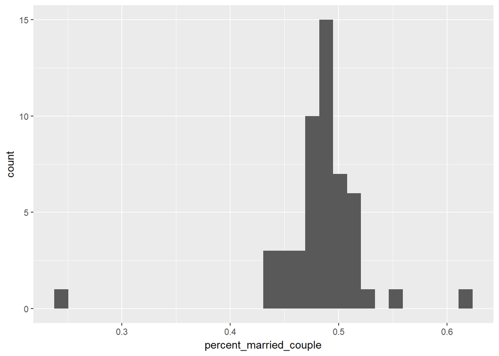

```r
qplot(percent_married_couple, geom = "histogram")
```